# Wk5Exercise

Matt Ming

2/21/2022

# Set up

Loading in the tidyverse packages to enable the later functions

```r
library(dplyr)
library(ggplot2)
library(tidyverse)
library(mosaic)
```

# Challenge 1

First, let’s load the IMDb dataset

```r
f <- "https://raw.githubusercontent.com/difiore/ada-2022-datasets/master/IMDB-movies.csv"
data <- read_csv(f,col_names = TRUE)
head(data)
```

```
## # A tibble: 6 x 10
##   tconst    titleType primaryTitle startYear runtimeMinutes genres averageRating
##   <chr>     <chr>     <chr>            <dbl>          <dbl> <chr>          <dbl>
## 1 tt0002130 movie     Dante's Inf~      1911             68 Adven~           7
## 2 tt0002844 movie     Fantômas: I~      1913             54 Crime~           7
## 3 tt0003037 movie     Fantomas: T~      1913             61 Crime~           7
## 4 tt0003165 movie     Fantômas: T~      1913             90 Crime~           7
## 5 tt0003419 movie     The Student~      1913             85 Drama~           6.5
## 6 tt0003643 movie     The Avengin~      1914             78 Crime~           6.5
## # ... with 3 more variables: numVotes <dbl>, nconst <chr>, director <chr>
```

Now, filter the data by only those movies with runtime between 1 - 3 hours and made between the years 1920 - 1979. We should be left with a dataframe with 5651 observations

```r
data <- data %>%
  filter(runtimeMinutes %in% 60:180 & startYear %in% 1920:1979) %>%
  mutate(decade = case_when(startYear %in% 1920:1929 ~ "20s",
                            startYear %in% 1930:1939 ~ "30s",
                            startYear %in% 1940:1949 ~ "40s",
                            startYear %in% 1950:1959 ~ "50s",
                            startYear %in% 1960:1969 ~ "60s",
                            startYear %in% 1970:1979 ~ "70s"))
```

Now, using ggplot to get a histogram of the distribution of runtimeMinutes for each decade. (Hint: use facet_wrap())

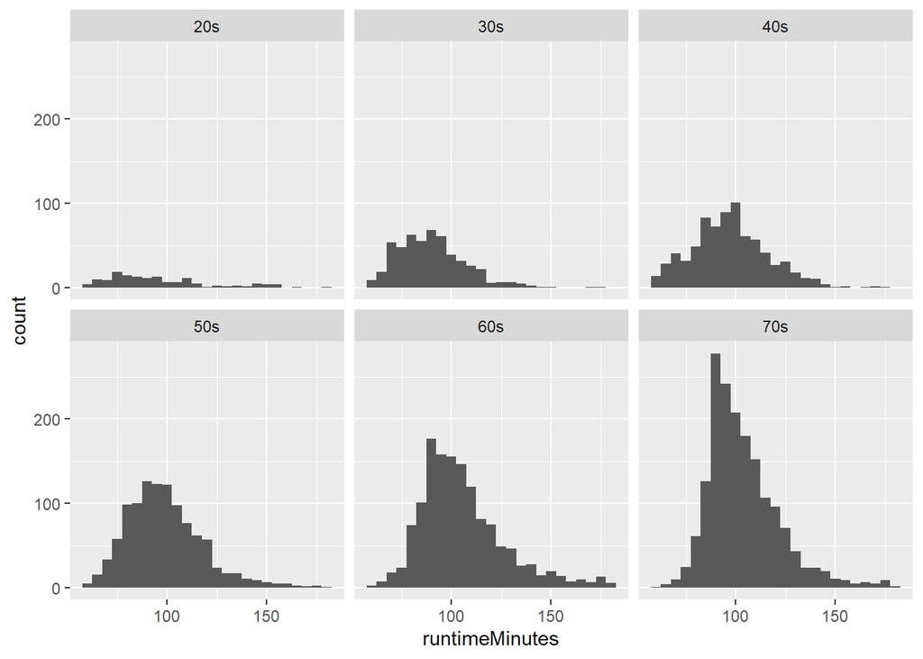

```r
p <- ggplot(data,aes(runtimeMinutes)) + facet_wrap(~decade,ncol = 3) +
  geom_histogram(binwidth = 5)
print(p)
```

Getting the mean and standard deviation for movie runtimes in minutes per decade then save the calculations in a new dataframe called **results**

```r
results <- data %>% select(runtimeMinutes,decade) %>% group_by(decade) %>%
  summarize(runtimes_means = mean(runtimeMinutes),
            runtimes_sds = sd(runtimeMinutes))
```

Drawing samples of 100 movies from each decade and calculating the single-sample mean and sd in runtimeMinutes per decade. We can then use the single-sample sd and sample size to estimate the standard error by the formula  
$SE\approx\sigma_x/\sqrt{n}$ where $\sigma_x$ = sd of the sample, and $n$ = sample size. We then want to compare these estimates to SE estimates using the population mean and sd (again using sample size of 100)

```r
results <- results %>% mutate(sample_mean = rep(0,6),
                              sample_sd = rep(0,6),
                              runtimes_se = rep(0,6),
                              sample_se = rep(0,6))
for(i in seq(20,70,by=10)){
  decstr <- paste0(i,"s")
  samplei <- data %>% filter(decade == decstr) %>% sample_n(size=100)
  results[(i/10)-1,] <- results %>% filter(decade == decstr) %>%
    mutate(sample_mean = mean(samplei$runtimeMinutes),
                     sample_sd = sd(samplei$runtimeMinutes)) %>%
    mutate(runtimes_se = runtimes_sds/10,
           sample_se = sample_sd/10)
}
results <- results %>% select(decade,runtimes_means,sample_mean,
                              runtimes_sds,sample_sd,
                              runtimes_se,sample_se)
head(results)
```

```
## # A tibble: 6 x 7
##   decade runtimes_means sample_mean runtimes_sds sample_sd runtimes_se sample_se
##   <chr>           <dbl>       <dbl>        <dbl>     <dbl>       <dbl>     <dbl>
## 1 20s              96.3        98.3         26.2      26.7        2.62      2.67
## 2 30s              90.3        91.5         17.3      17.4        1.73      1.74
## 3 40s              97.2        97.2         19.1      17.8        1.91      1.78
## 4 50s              98.9        96.9         19.2      17.7        1.92      1.77
## 5 60s             106.        110.          21.2      22.4        2.12      2.24
## 6 70s             104.        105.          18.0      19.4        1.80      1.94
```

Now, we’re going to generate a sampling distribution by sampling 100 movies from each decade 1000 times, and getting the mean for each of those 1000 samples and plot them. We then want to compare the standard error found from this sampling with the SE calculated using the sample sd and population sd calculated earlier.

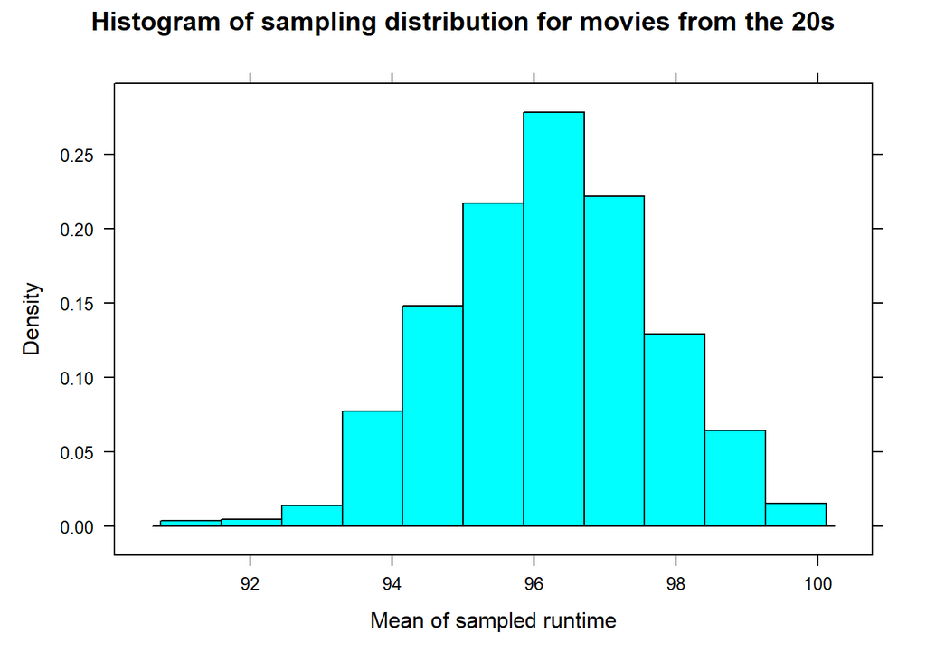

```
## [1] "Comparing estimates of SE"
## [1] "Decade = 20s"
## [1] "Sampling Dist SE = 1.20356081607738"
## [1] "Sample SE        = 2.66762463853542"
## [1] "Population SE    = 2.62013337486023"
```

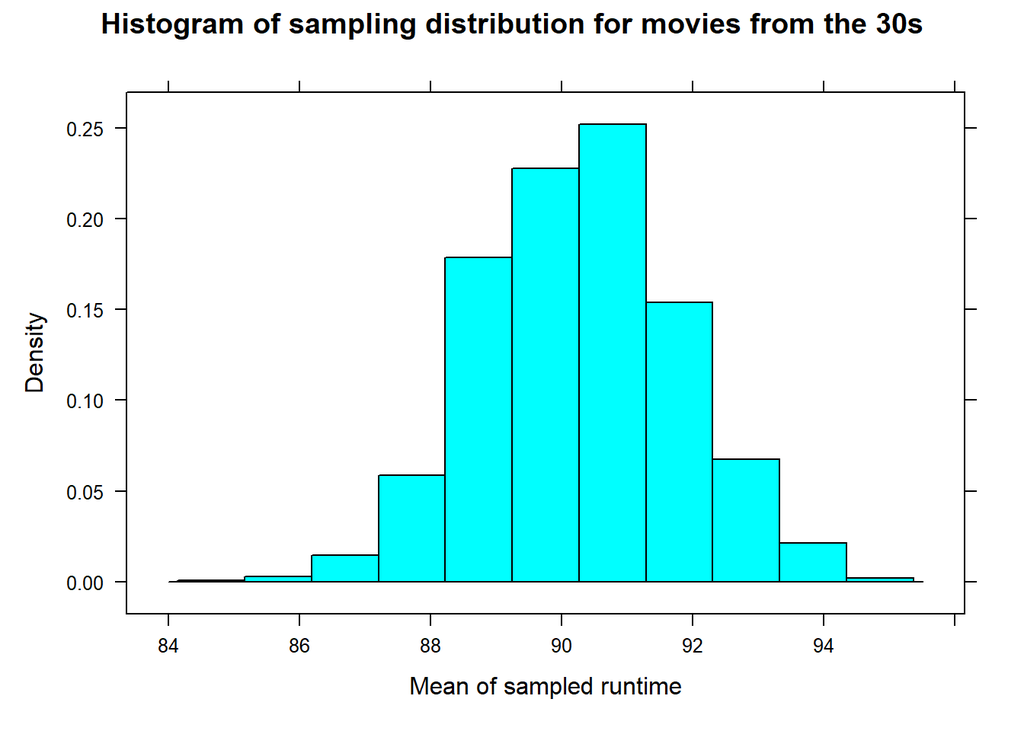

```
## [1] "Comparing estimates of SE"
## [1] "Decade = 30s"
## [1] "Sampling Dist SE = 1.51893842816916"
## [1] "Sample SE        = 1.73842463225191"
## [1] "Population SE    = 1.7288790253543"
```

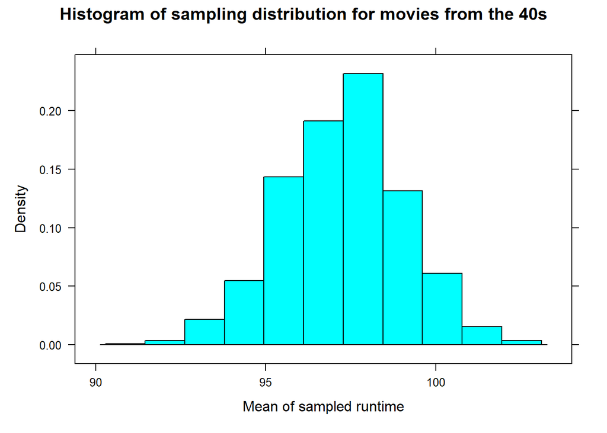

```
## [1] "Comparing estimates of SE"
## [1] "Decade = 40s"
## [1] "Sampling Dist SE = 1.45926836614969"
## [1] "Sample SE        = 1.78322033060268"
## [1] "Population SE    = 1.91237184838568"
```

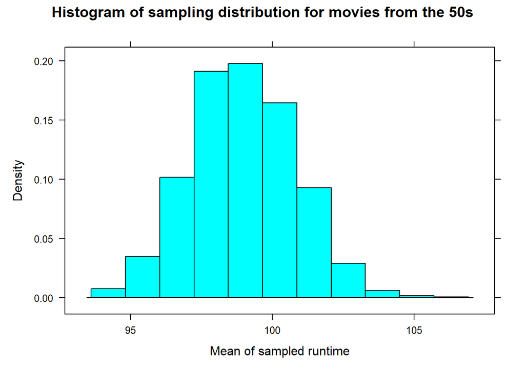

```
## [1] "Comparing estimates of SE"
## [1] "Decade = 50s"
## [1] "Sampling Dist SE = 1.66864640329768"
## [1] "Sample SE        = 1.76627668651696"
## [1] "Population SE    = 1.92064586692434"
```

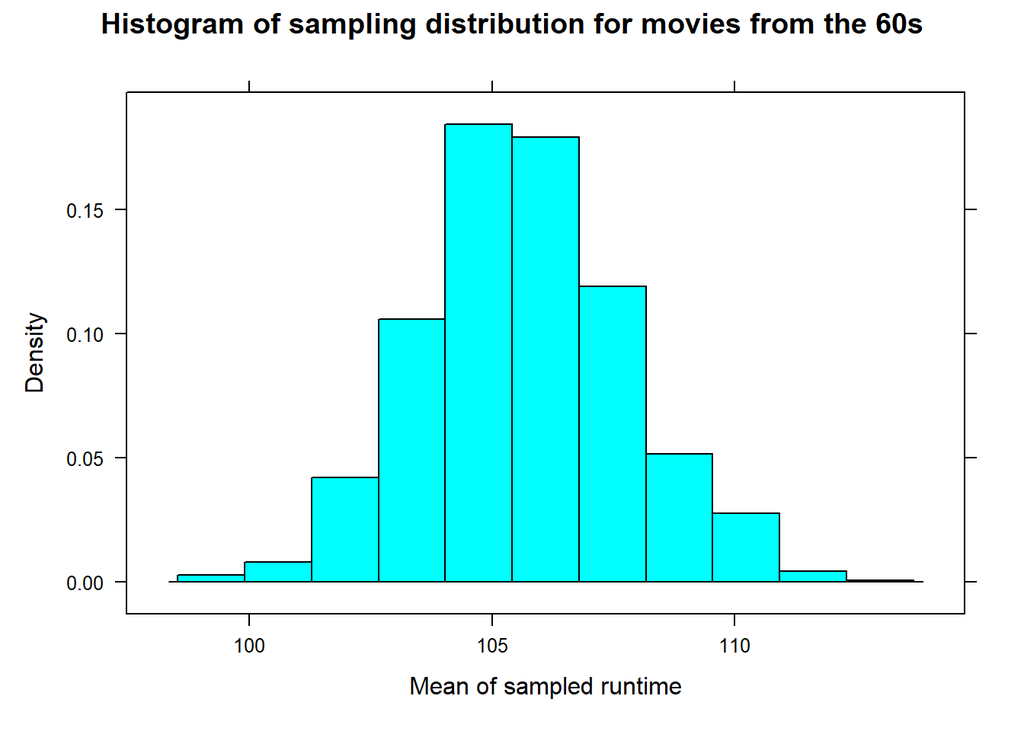

```
## [1] "Comparing estimates of SE"
## [1] "Decade = 60s"
## [1] "Sampling Dist SE = 1.83809820709638"
## [1] "Sample SE        = 2.23698818986962"
## [1] "Population SE    = 2.12320220460705"
```

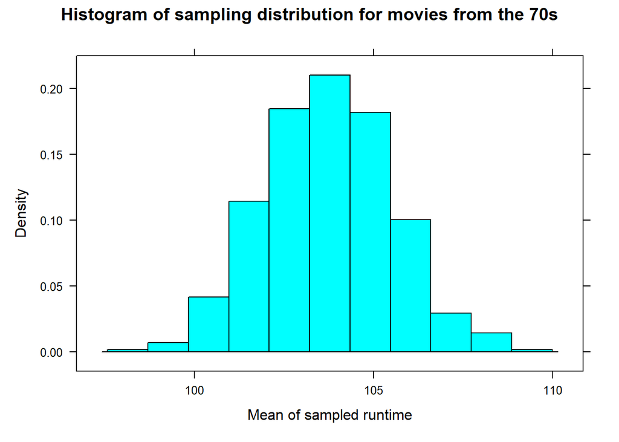

```
## [1] "Comparing estimates of SE"
## [1] "Decade = 70s"
## [1] "Sampling Dist SE = 1.79446000757605"
## [1] "Sample SE        = 1.94133766233284"
## [1] "Population SE    = 1.79593377573281"
```

```r
for(i in seq(20,70,by = 10)){
  decstr <- paste0(i,"s")
  decsamps <- data.frame(means = rep(0,1000),sds = rep(0,1000))
  dec_pop <- data %>% filter(decade == decstr) %>% select(runtimeMinutes)
  decsamps$means <- (do(1000) * mean(sample(dec_pop$runtimeMinutes,100)))$mean
  decsamps$sds <- (do(1000) * sd(sample(dec_pop$runtimeMinutes,100)))$sd

  sampdist_mean <- mean(decsamps$means)
  sampdist_sd <- sd(decsamps$sds)
  print(histogram(decsamps$means,
            main = paste("Histogram of sampling distribution for movies from the",decstr),
            xlab = "Mean of sampled runtime"))

  print("Comparing estimates of SE")
  print(paste("Decade =",decstr))
  print(paste("Sampling Dist SE =",sampdist_sd))
  print(paste("Sample SE        =",results$sample_se[which(results$decade == decstr)]))
  print(paste("Population SE    =",results$runtimes_se[which(results$decade == decstr)]))
  cat("\n")
}
```

Visually inspecting the histograms produced, we can see that the sampling distribution in every decade is approximately normally distributed.

# Challenge 2

We’ll now switch to a second dataset, which will be loaded in here:

```r
f <- "https://raw.githubusercontent.com/difiore/ada-2022-datasets/main/zombies.csv"
data2 <- read_csv(f,col_names = TRUE)
head(data2)
```

```
## # A tibble: 6 x 10
##      id first_name last_name gender height weight zombies_killed
##   <dbl> <chr>      <chr>     <chr>   <dbl>  <dbl>          <dbl>
## 1     1 Sarah      Little    Female   62.9   132.              2
## 2     2 Mark       Duncan    Male     67.8   146.              5
## 3     3 Brandon    Perez     Male     72.1   153.              1
## 4     4 Roger      Coleman   Male     66.8   130.              5
## 5     5 Tammy      Powell    Female   64.7   132.              4
## 6     6 Anthony    Green     Male     71.2   153.              1
## # ... with 3 more variables: years_of_education <dbl>, major <chr>, age <dbl>
```

First, we’re going to calculate the population-level mean and standard deviation for each quantitative field, those fields being Height, Weight, Age, Zombies Killed, and Years of Education. Note that because we’re dealing with *population*-level statistics here, we’ll want to manually calculated the sd as $\sigma=\sqrt{SS/N}$ where $SS$ is the sum of squares, or the deviation of each data point from the mean.

```r
pop_stats <- data.frame(fields = c("height","weight","age","zombies_killed",
                                   "years_of_education"),
                        means = rep(0,5),SDs = rep(0,5))
for(i in pop_stats$fields){
  pop_stats[which(pop_stats$fields == i),"means"] <- mean(data2[[i]])
  pop_stats[which(pop_stats$fields == i),"SDs"] <-
    sqrt(sum((data2[[i]] - mean(data2[[i]]))^2)/length(data2[[i]]))
}
head(pop_stats)
```

```
##               fields     means       SDs
## 1             height  67.63010  4.307970
## 2             weight 143.90748 18.391857
## 3                age  20.04696  2.963583
## 4     zombies_killed   2.99200  1.747551
## 5 years_of_education   2.99600  1.675704
```

Now, to generate some plots using the data. First, we make boxplots for each of the above variables by gender.

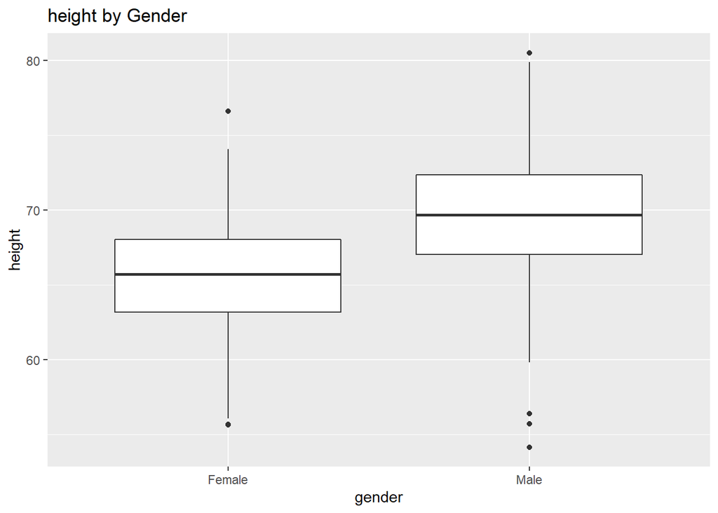

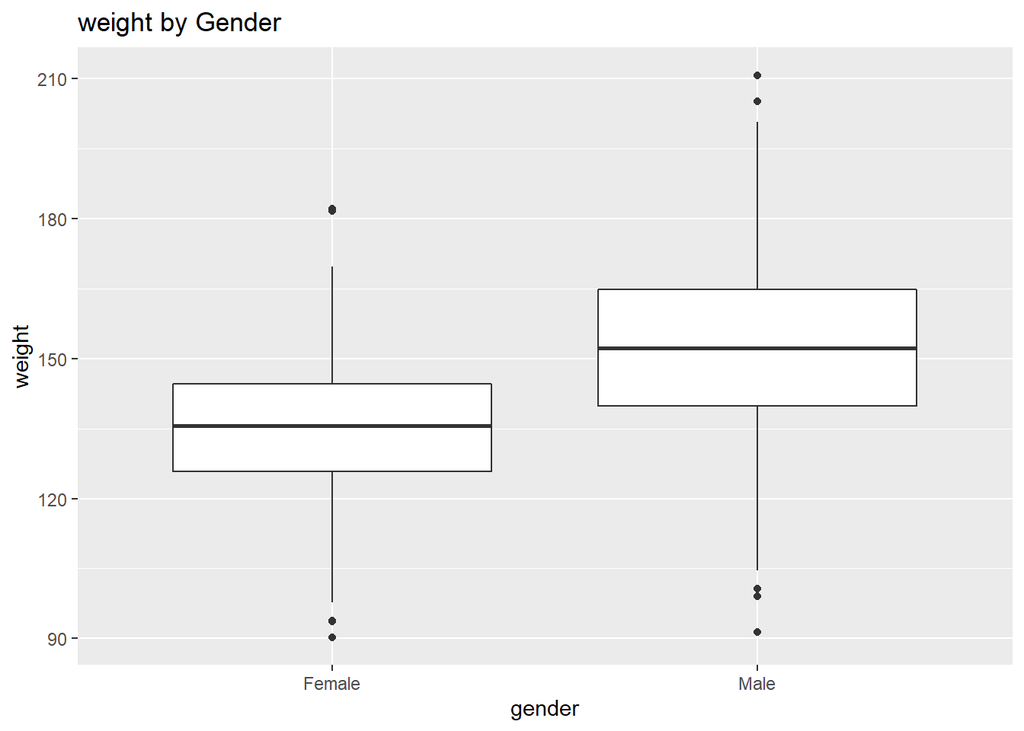

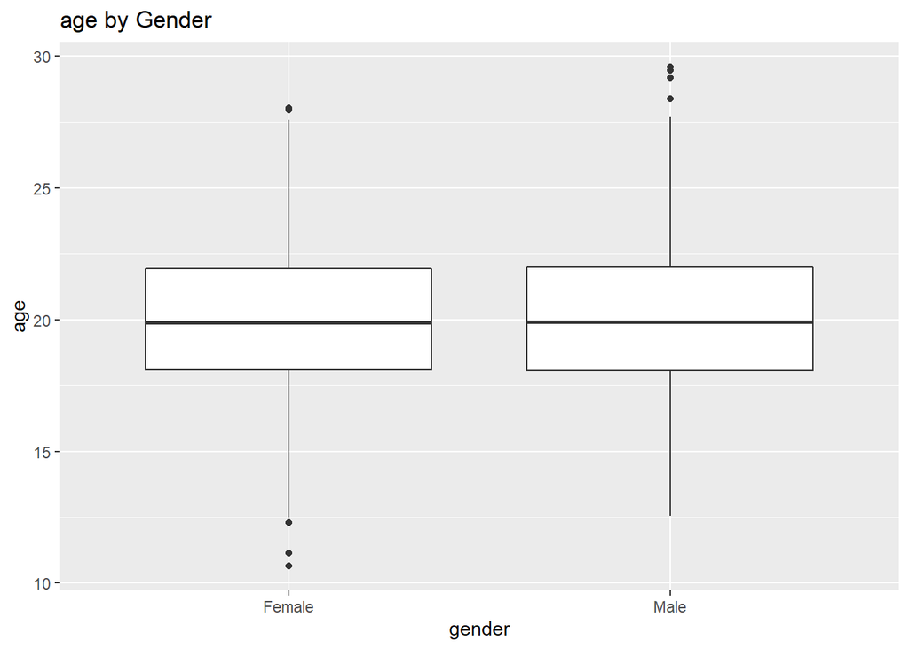

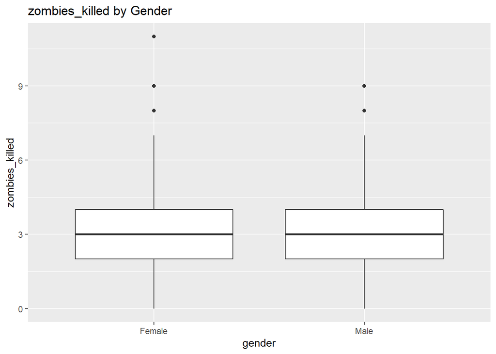

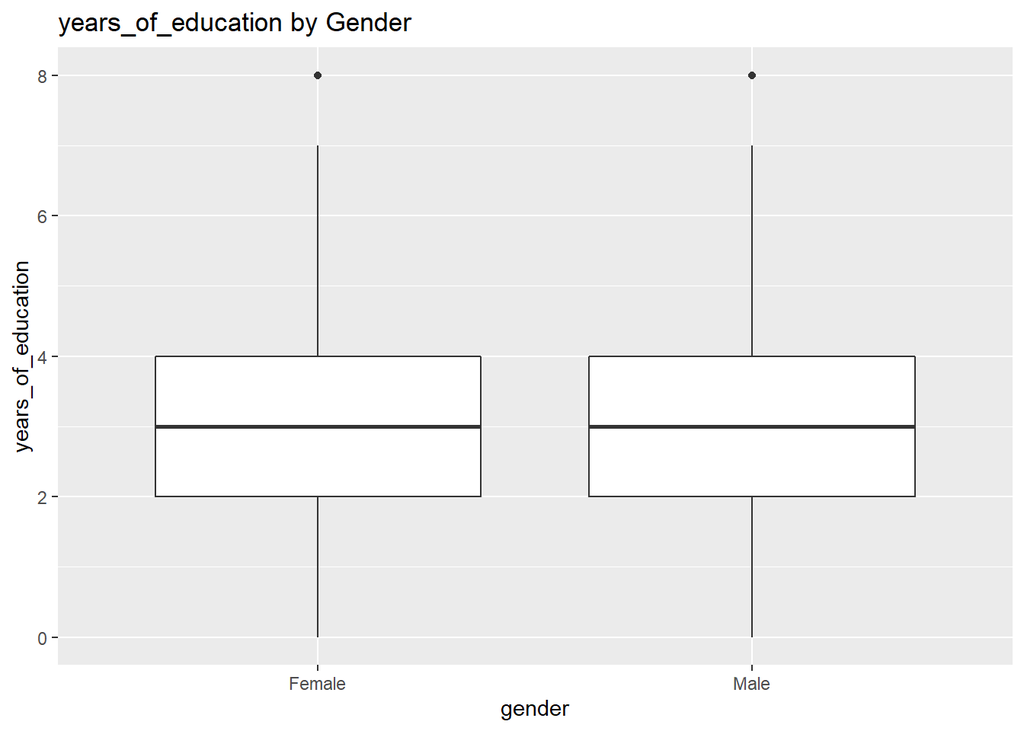

```r
for(i in pop_stats$fields){
  p <- ggplot(data2,aes_string(x = "gender",y = i)) + geom_boxplot() +
    ggtitle(paste(i,"by Gender"))
  print(p)
}
```

Now, making a scatterplot of the relationship between height and age, and weight and age. Also, coloring each point by gender

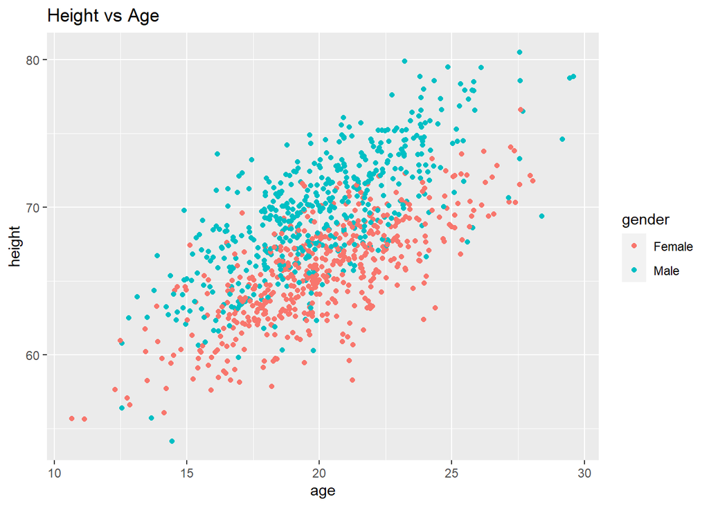

```r
p1 <- ggplot(data2,aes(x = age,y = height,color = gender)) + geom_point() +
  ggtitle("Height vs Age")
p2 <- ggplot(data2,aes(x = age,y = weight,color = gender)) + geom_point() +
  ggtitle("Weight vs Age")
print(p1)
```

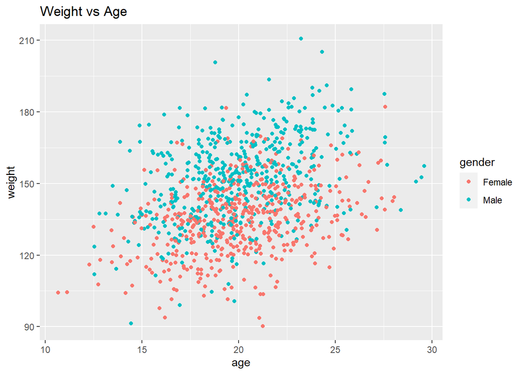

```r
print(p2)
```

When we generate these plots, we notice a few trends. First, we can see a very strong positive correlation between age and height, meaning that across the population, in general older age means taller height. Likewise, there is a very slight positive correlation between weight and age but it is not nearly as strongly positive and the clustering of points around the best-fit line is not as tight. We also see that height is very correlated with gender, as Males were, on average, significantly taller (~5 inches) than Females. Again, there was also a slight correlation between weight and gender, with Males being heavier on average than Females, but it is difficult to see this difference from the scatter plot as the variance in weight given a certain age is much greater for both genders. The difference in average weight between Males and Females is much more noticeable when comparing the boxplot of weight vs. gender.

We now want to examine the normality of each of the variables above. To do this we are going to first plot a histogram of the data and see if it looks approximately normal, then we’ll back up our findings using QQ plots.

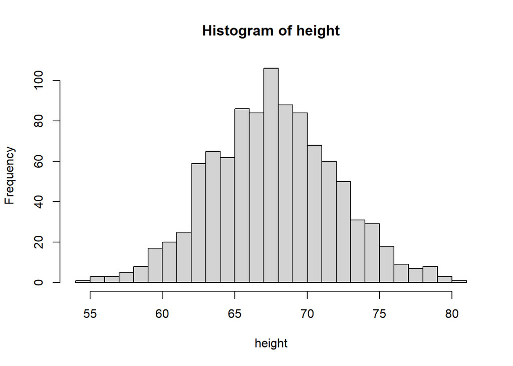

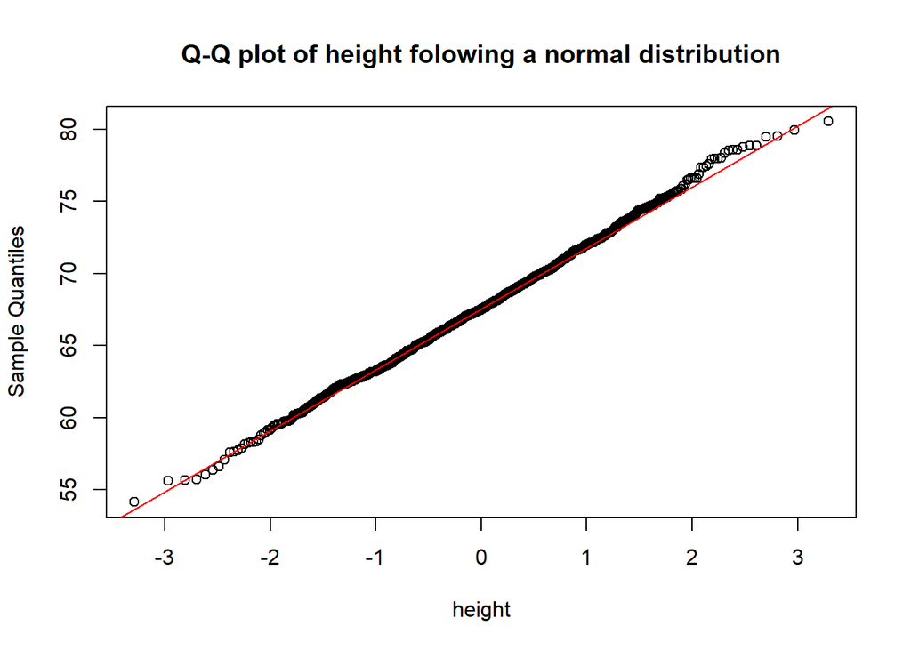

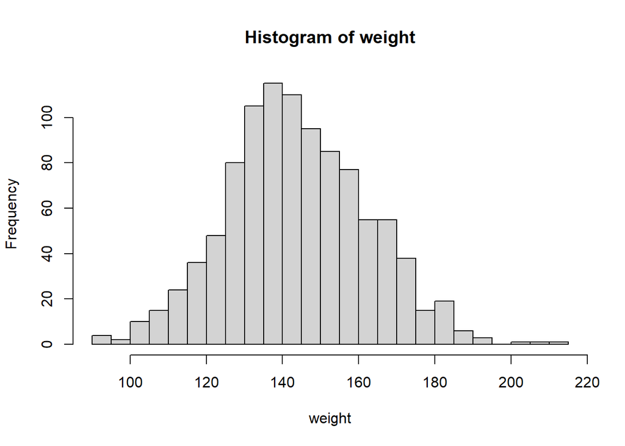

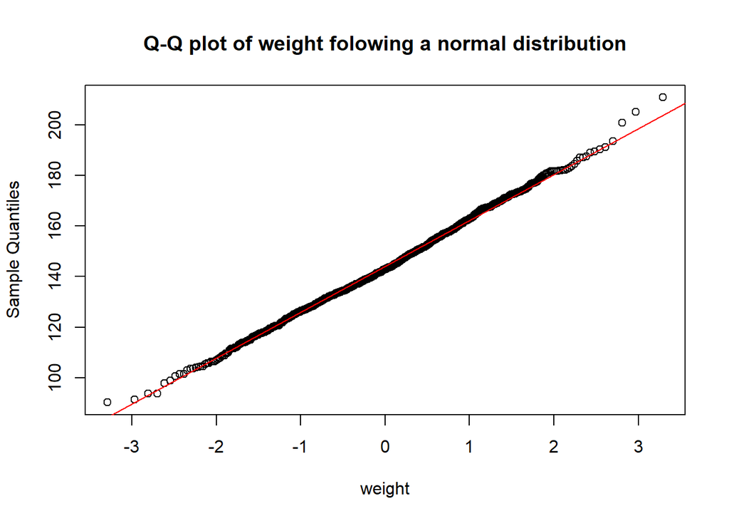

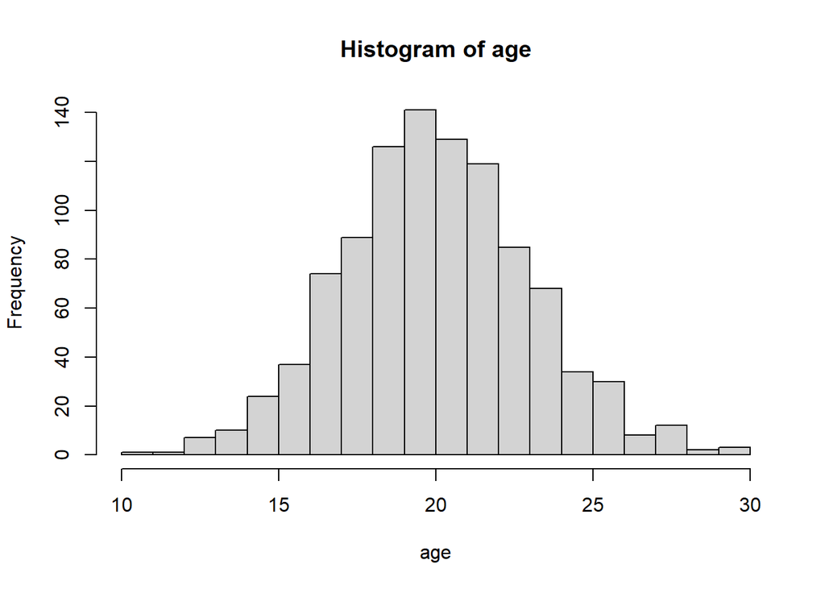

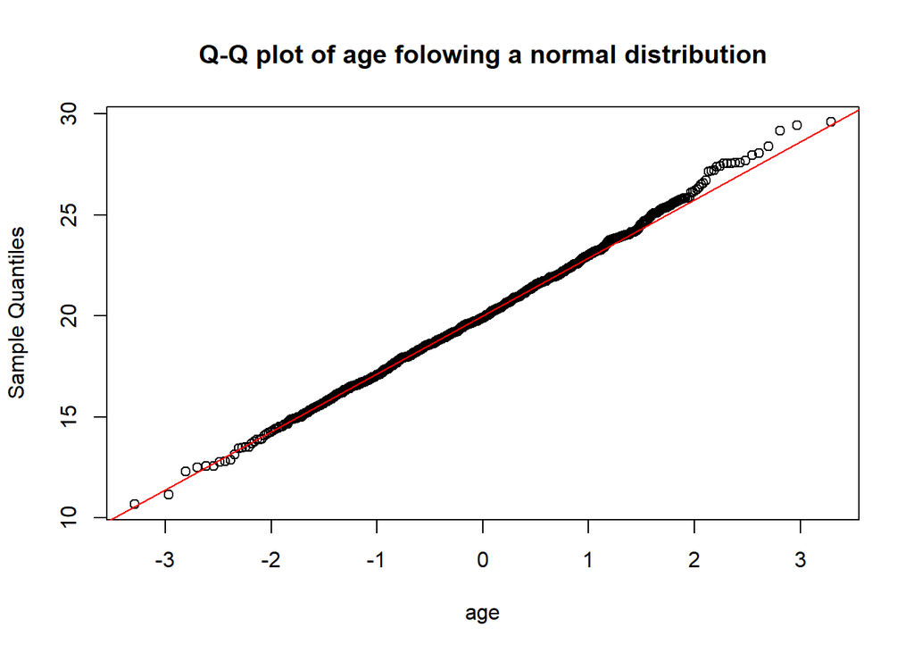

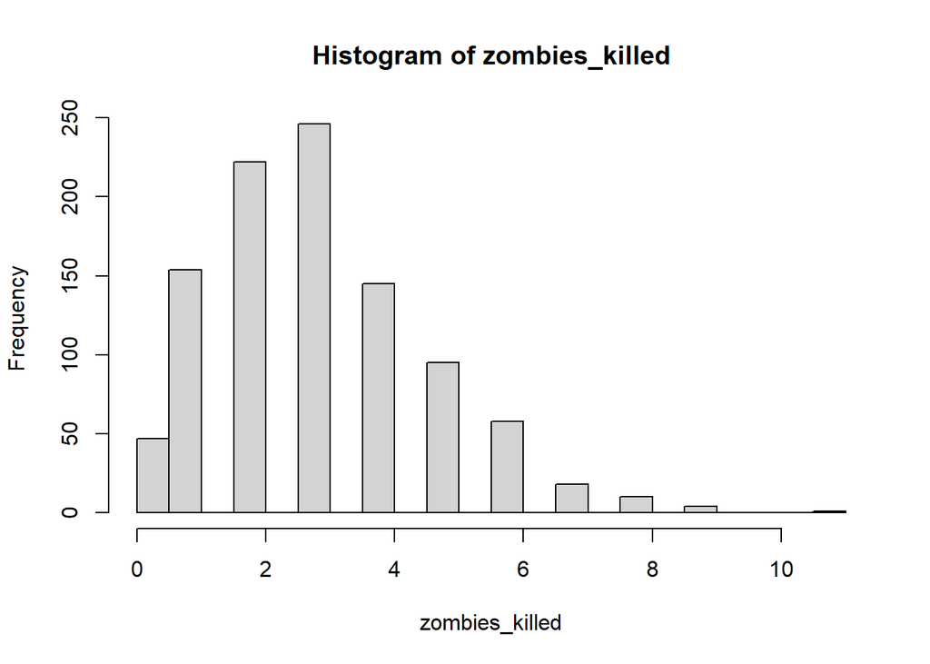

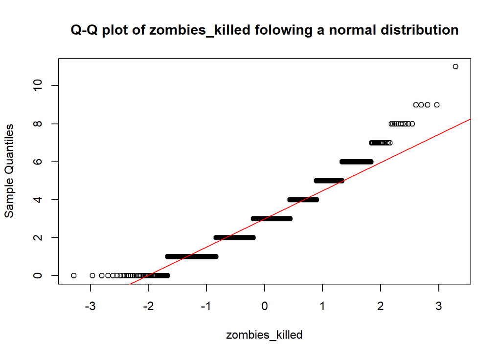

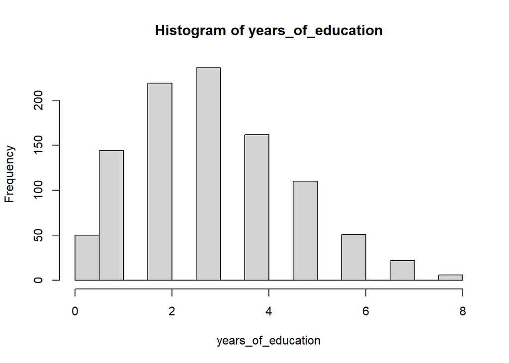

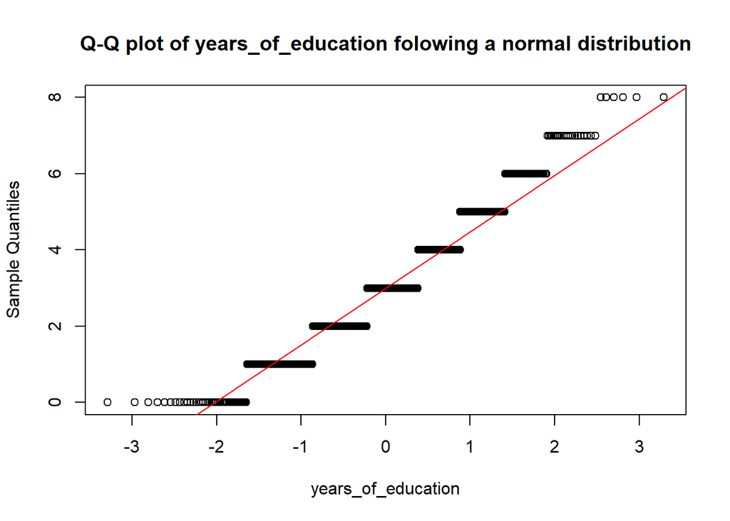

```r
for(i in pop_stats$fields){
  hist(data2[[i]],main = paste("Histogram of",i),xlab = i,breaks = 20)
  qqnorm(data2[[i]],
         main = paste("Q-Q plot of",i,"folowing a normal distribution"),
         xlab = i)
  qqline(data2[[i]],col = "red")
}
```

Visually inspecting these plots, it seems that height, weight, and age follow a normal distribution; this makes sense as each of these variables is continuous. However, the number of zombies killed and years of education variables do not follow a normal distribution because they are not continuous but are rather discrete variables (i.e., one cannot kill 2.7 zombies). Thus, it appears that these variables are drawn from a Poisson distribution (each with some unknown parameter $\lambda$)

Now, we’ll sample 50 survivors and calculating the mean and standard deviation, as well as an estimate of standard error from the sample SD for each variable. Again, we will use our knowledge of $SE\approx\sigma_x/\sqrt{n}$ to calculate SE at this step. We also want to calculate a 95% confidence interval for the single sample, which we can do by using the SE and knowing that 95% of a normal distribution falls between $\mu\pm1.96*SE$ where $\mu$ = sample mean; note that here we assume that the sampling distribution of means for each variable follows a normal distribution.

```r
survivor_samp <- sample_n(data2,50)
stats_tab <- data.frame(fields = c("height","weight","age","zombies_killed",
                                   "years_of_education"),
                        means = rep(0,5),SDs = rep(0,5),SEs = rep(0,5),
                        lower_ci = rep(0,5),upper_ci = rep(0,5))
for(i in 1:5){
  stats_tab[i,"means"] <- mean(survivor_samp[[stats_tab$fields[i]]])
  stats_tab[i,"SDs"] <- sd(survivor_samp[[stats_tab$fields[i]]])
  stats_tab[i,"SEs"] <- stats_tab[i,"SDs"]/sqrt(50)
  stats_tab[i,"lower_ci"] <- stats_tab[i,"means"] +
    stats_tab[i,"SEs"]*qnorm(0.025)
  stats_tab[i,"upper_ci"] <- stats_tab[i,"means"] +
    stats_tab[i,"SEs"]*qnorm(0.975)
}
print(stats_tab)
```

```
##               fields     means       SDs       SEs   lower_ci   upper_ci
## 1             height  67.97711  3.735817 0.5283244  66.941618  69.012611
## 2             weight 146.48529 14.804001 2.0936019 142.381906 150.588675
## 3                age  20.23267  3.297632 0.4663556  19.318627  21.146707
## 4     zombies_killed   2.94000  1.811640 0.2562046   2.437848   3.442152
## 5 years_of_education   3.38000  1.839365 0.2601256   2.870163   3.889837
```

We’ll now perform this same sampling 200 times to develop a sampling distribution for each variable, and use these sampling distributions to calculate SE. We will also use the SEs calculated to estimate 95% confidence intervals for the mean of each variable.